# Risk Factor Analysis

## Outcome Variable

**Outcome Variable:** sstunted

## Predictor Variables

**Intervention Variable:** anywast06

**Adjustment Set:**

- arm
- sex
- brthmon
- W_mage
- meducyrs
- hhwealth_quart
- W_nrooms
- month
- W_parity
- delta_W_mage
- delta_meducyrs
- delta_hhwealth_quart
- delta_W_nrooms
- delta_month
- delta_W_parity

## Stratifying Variables

The analysis was stratified on these variable(s):

- agecat
- studyid
- country

## Data Summary

| agecat | studyid | country | anywast06 | sstunted | n_cell | n |
| --- | --- | --- | --- | --- | --- | --- |
| Birth | ki0047075b-MAL-ED | BANGLADESH | 0 | 0 | 170 | 229 |
| Birth | ki0047075b-MAL-ED | BANGLADESH | 0 | 1 | 7 | 229 |
| Birth | ki0047075b-MAL-ED | BANGLADESH | 1 | 0 | 50 | 229 |
| Birth | ki0047075b-MAL-ED | BANGLADESH | 1 | 1 | 2 | 229 |
| Birth | ki0047075b-MAL-ED | BRAZIL | 0 | 0 | 59 | 65 |
| Birth | ki0047075b-MAL-ED | BRAZIL | 0 | 1 | 3 | 65 |
| Birth | ki0047075b-MAL-ED | BRAZIL | 1 | 0 | 3 | 65 |
| Birth | ki0047075b-MAL-ED | BRAZIL | 1 | 1 | 0 | 65 |
| Birth | ki0047075b-MAL-ED | INDIA | 0 | 0 | 32 | 47 |
| Birth | ki0047075b-MAL-ED | INDIA | 0 | 1 | 1 | 47 |
| Birth | ki0047075b-MAL-ED | INDIA | 1 | 0 | 13 | 47 |
| Birth | ki0047075b-MAL-ED | INDIA | 1 | 1 | 1 | 47 |
| Birth | ki0047075b-MAL-ED | NEPAL | 0 | 0 | 22 | 27 |
| Birth | ki0047075b-MAL-ED | NEPAL | 0 | 1 | 1 | 27 |
| Birth | ki0047075b-MAL-ED | NEPAL | 1 | 0 | 4 | 27 |
| Birth | ki0047075b-MAL-ED | NEPAL | 1 | 1 | 0 | 27 |
| Birth | ki0047075b-MAL-ED | PERU | 0 | 0 | 219 | 233 |
| Birth | ki0047075b-MAL-ED | PERU | 0 | 1 | 4 | 233 |
| Birth | ki0047075b-MAL-ED | PERU | 1 | 0 | 10 | 233 |
| Birth | ki0047075b-MAL-ED | PERU | 1 | 1 | 0 | 233 |
| Birth | ki0047075b-MAL-ED | SOUTH AFRICA | 0 | 0 | 100 | 122 |
| Birth | ki0047075b-MAL-ED | SOUTH AFRICA | 0 | 1 | 1 | 122 |
| Birth | ki0047075b-MAL-ED | SOUTH AFRICA | 1 | 0 | 21 | 122 |
| Birth | ki0047075b-MAL-ED | SOUTH AFRICA | 1 | 1 | 0 | 122 |
| Birth | ki0047075b-MAL-ED | TANZANIA, UNITED REPUBLIC OF | 0 | 0 | 110 | 124 |
| Birth | ki0047075b-MAL-ED | TANZANIA, UNITED REPUBLIC OF | 0 | 1 | 9 | 124 |
| Birth | ki0047075b-MAL-ED | TANZANIA, UNITED REPUBLIC OF | 1 | 0 | 5 | 124 |
| Birth | ki0047075b-MAL-ED | TANZANIA, UNITED REPUBLIC OF | 1 | 1 | 0 | 124 |
| Birth | ki1000108-CMC-V-BCS-2002 | INDIA | 0 | 0 | 37 | 92 |
| Birth | ki1000108-CMC-V-BCS-2002 | INDIA | 0 | 1 | 0 | 92 |

[output cut: 170 more lines]

The following strata were considered:

- agecat: 24 months, studyid: ki0047075b-MAL-ED, country: BANGLADESH
- agecat: 24 months, studyid: ki0047075b-MAL-ED, country: BRAZIL
- agecat: 24 months, studyid: ki0047075b-MAL-ED, country: INDIA
- agecat: 24 months, studyid: ki0047075b-MAL-ED, country: NEPAL
- agecat: 24 months, studyid: ki0047075b-MAL-ED, country: PERU
- agecat: 24 months, studyid: ki0047075b-MAL-ED, country: SOUTH AFRICA
- agecat: 24 months, studyid: ki0047075b-MAL-ED, country: TANZANIA, UNITED REPUBLIC OF
- agecat: 24 months, studyid: ki1000108-CMC-V-BCS-2002, country: INDIA
- agecat: 24 months, studyid: ki1000108-IRC, country: INDIA
- agecat: 24 months, studyid: ki1000109-EE, country: PAKISTAN
- agecat: 24 months, studyid: ki1017093b-PROVIDE, country: BANGLADESH
- agecat: 24 months, studyid: ki1066203-TanzaniaChild2, country: TANZANIA, UNITED REPUBLIC OF
- agecat: 24 months, studyid: ki1101329-Keneba, country: GAMBIA
- agecat: 24 months, studyid: ki1113344-GMS-Nepal, country: NEPAL
- agecat: 24 months, studyid: ki1114097-CMIN, country: BANGLADESH
- agecat: 24 months, studyid: ki1114097-CONTENT, country: PERU
- agecat: 6 months, studyid: ki0047075b-MAL-ED, country: BANGLADESH
- agecat: 6 months, studyid: ki0047075b-MAL-ED, country: BRAZIL
- agecat: 6 months, studyid: ki0047075b-MAL-ED, country: INDIA
- agecat: 6 months, studyid: ki0047075b-MAL-ED, country: NEPAL
- agecat: 6 months, studyid: ki0047075b-MAL-ED, country: PERU
- agecat: 6 months, studyid: ki0047075b-MAL-ED, country: SOUTH AFRICA
- agecat: 6 months, studyid: ki0047075b-MAL-ED, country: TANZANIA, UNITED REPUBLIC OF
- agecat: 6 months, studyid: ki1000108-CMC-V-BCS-2002, country: INDIA
- agecat: 6 months, studyid: ki1000108-IRC, country: INDIA
- agecat: 6 months, studyid: ki1000109-EE, country: PAKISTAN
- agecat: 6 months, studyid: ki1000109-ResPak, country: PAKISTAN
- agecat: 6 months, studyid: ki1017093b-PROVIDE, country: BANGLADESH
- agecat: 6 months, studyid: ki1066203-TanzaniaChild2, country: TANZANIA, UNITED REPUBLIC OF
- agecat: 6 months, studyid: ki1101329-Keneba, country: GAMBIA
- agecat: 6 months, studyid: ki1112895-Guatemala BSC, country: GUATEMALA
- agecat: 6 months, studyid: ki1113344-GMS-Nepal, country: NEPAL
- agecat: 6 months, studyid: ki1114097-CMIN, country: BANGLADESH
- agecat: 6 months, studyid: ki1114097-CONTENT, country: PERU
- agecat: Birth, studyid: ki0047075b-MAL-ED, country: BANGLADESH
- agecat: Birth, studyid: ki0047075b-MAL-ED, country: BRAZIL
- agecat: Birth, studyid: ki0047075b-MAL-ED, country: INDIA
- agecat: Birth, studyid: ki0047075b-MAL-ED, country: NEPAL
- agecat: Birth, studyid: ki0047075b-MAL-ED, country: PERU
- agecat: Birth, studyid: ki0047075b-MAL-ED, country: SOUTH AFRICA
- agecat: Birth, studyid: ki0047075b-MAL-ED, country: TANZANIA, UNITED REPUBLIC OF
- agecat: Birth, studyid: ki1000108-CMC-V-BCS-2002, country: INDIA
- agecat: Birth, studyid: ki1000108-IRC, country: INDIA
- agecat: Birth, studyid: ki1000109-EE, country: PAKISTAN
- agecat: Birth, studyid: ki1000109-ResPak, country: PAKISTAN
- agecat: Birth, studyid: ki1017093b-PROVIDE, country: BANGLADESH
- agecat: Birth, studyid: ki1101329-Keneba, country: GAMBIA
- agecat: Birth, studyid: ki1113344-GMS-Nepal, country: NEPAL
- agecat: Birth, studyid: ki1114097-CMIN, country: BANGLADESH
- agecat: Birth, studyid: ki1114097-CONTENT, country: PERU

### Dropped Strata

Some strata were dropped due to rare outcomes:

- agecat: Birth, studyid: ki0047075b-MAL-ED, country: BANGLADESH
- agecat: Birth, studyid: ki0047075b-MAL-ED, country: BRAZIL
- agecat: Birth, studyid: ki0047075b-MAL-ED, country: INDIA
- agecat: Birth, studyid: ki0047075b-MAL-ED, country: NEPAL
- agecat: Birth, studyid: ki0047075b-MAL-ED, country: PERU
- agecat: Birth, studyid: ki0047075b-MAL-ED, country: SOUTH AFRICA
- agecat: Birth, studyid: ki0047075b-MAL-ED, country: TANZANIA, UNITED REPUBLIC OF
- agecat: Birth, studyid: ki1000108-CMC-V-BCS-2002, country: INDIA
- agecat: Birth, studyid: ki1000109-ResPak, country: PAKISTAN
- agecat: Birth, studyid: ki1017093b-PROVIDE, country: BANGLADESH
- agecat: Birth, studyid: ki1114097-CMIN, country: BANGLADESH
- agecat: Birth, studyid: ki1114097-CONTENT, country: PERU
- agecat: 6 months, studyid: ki0047075b-MAL-ED, country: BANGLADESH
- agecat: 6 months, studyid: ki0047075b-MAL-ED, country: BRAZIL
- agecat: 6 months, studyid: ki0047075b-MAL-ED, country: INDIA
- agecat: 6 months, studyid: ki0047075b-MAL-ED, country: NEPAL
- agecat: 6 months, studyid: ki0047075b-MAL-ED, country: PERU
- agecat: 6 months, studyid: ki0047075b-MAL-ED, country: SOUTH AFRICA
- agecat: 6 months, studyid: ki0047075b-MAL-ED, country: TANZANIA, UNITED REPUBLIC OF
- agecat: 6 months, studyid: ki1066203-TanzaniaChild2, country: TANZANIA, UNITED REPUBLIC OF
- agecat: 6 months, studyid: ki1112895-Guatemala BSC, country: GUATEMALA
- agecat: 6 months, studyid: ki1114097-CONTENT, country: PERU
- agecat: 24 months, studyid: ki0047075b-MAL-ED, country: BRAZIL
- agecat: 24 months, studyid: ki0047075b-MAL-ED, country: NEPAL
- agecat: 24 months, studyid: ki0047075b-MAL-ED, country: PERU
- agecat: 24 months, studyid: ki0047075b-MAL-ED, country: TANZANIA, UNITED REPUBLIC OF
- agecat: 24 months, studyid: ki1066203-TanzaniaChild2, country: TANZANIA, UNITED REPUBLIC OF
- agecat: 24 months, studyid: ki1114097-CONTENT, country: PERU

## Methods Detail

We’re interested in the causal parameters $E[Y_a]$ for all values of $a \in \mathcal{A}$. These parameters represent the mean outcome if, possibly contrary to fact, we intervened to set all units to have $A=a$. Under the randomization and positivity assumptions, these are identified by the statistical parameters $\psi_a=E_W[E_{Y|A,W}(Y|A=a,W)]$. In addition, we’re interested in the mean of $Y$, $E[Y]$ under no intervention (the observed mean). We will estimate these parameters by using SuperLearner to fit the relevant likelihood factors – $E_{Y|A,W}(Y|A=a,W)$ and $p(A=a|W)$, and then updating our likelihood fit using a joint TMLE.

For unadjusted analyses ($W=\{\}$), initial likelihoods were estimated using Lrnr_glm to estimate the simple $E(Y|A)$ and Lrnr_mean to estimate $p(A)$. For adjusted analyses, a small library containing Lrnr_glmnet, Lrnr_xgboost, and Lrnr_mean was used.

Having estimated these parameters, we will then use the delta method to estimate relative risks and attributable risks relative to a prespecified baseline level of $A$.

# Results Detail

## Results Plots

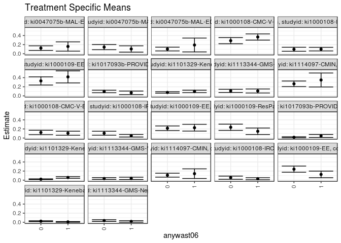

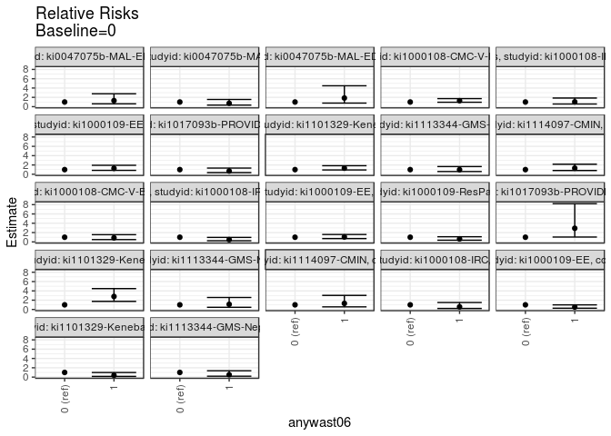

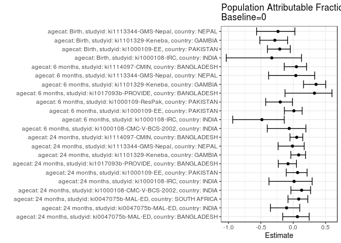

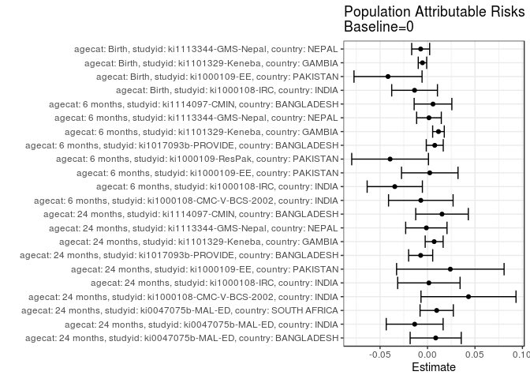

## Results Table

### Parameter: TSM

| agecat | studyid | country | intervention_level | baseline_level | estimate | ci_lower | ci_upper |
| --- | --- | --- | --- | --- | --- | --- | --- |
| Birth | ki1000108-IRC | INDIA | 0 | NA | 0.0548780 | 0.0199777 | 0.0897784 |
| Birth | ki1000108-IRC | INDIA | 1 | NA | 0.0312500 | 0.0084353 | 0.0540647 |
| Birth | ki1000109-EE | PAKISTAN | 0 | NA | 0.2416208 | 0.1737791 | 0.3094625 |
| Birth | ki1000109-EE | PAKISTAN | 1 | NA | 0.1261039 | 0.0534596 | 0.1987481 |
| Birth | ki1101329-Keneba | GAMBIA | 0 | NA | 0.0241449 | 0.0145993 | 0.0336904 |
| Birth | ki1101329-Keneba | GAMBIA | 1 | NA | 0.0091241 | 0.0011606 | 0.0170876 |
| Birth | ki1113344-GMS-Nepal | NEPAL | 0 | NA | 0.0379147 | 0.0196791 | 0.0561503 |
| Birth | ki1113344-GMS-Nepal | NEPAL | 1 | NA | 0.0190840 | 0.0025047 | 0.0356632 |
| 6 months | ki1000108-CMC-V-BCS-2002 | INDIA | 0 | NA | 0.1221359 | 0.0732715 | 0.1710004 |
| 6 months | ki1000108-CMC-V-BCS-2002 | INDIA | 1 | NA | 0.1060050 | 0.0618241 | 0.1501859 |
| 6 months | ki1000108-IRC | INDIA | 0 | NA | 0.1057688 | 0.0622042 | 0.1493333 |
| 6 months | ki1000108-IRC | INDIA | 1 | NA | 0.0507260 | 0.0226602 | 0.0787918 |
| 6 months | ki1000109-EE | PAKISTAN | 0 | NA | 0.2147938 | 0.1639240 | 0.2656636 |
| 6 months | ki1000109-EE | PAKISTAN | 1 | NA | 0.2268084 | 0.1526421 | 0.3009747 |
| 6 months | ki1000109-ResPak | PAKISTAN | 0 | NA | 0.2360807 | 0.1677810 | 0.3043804 |
| 6 months | ki1000109-ResPak | PAKISTAN | 1 | NA | 0.1483758 | 0.0766771 | 0.2200744 |
| 6 months | ki1017093b-PROVIDE | BANGLADESH | 0 | NA | 0.0155556 | 0.0041126 | 0.0269986 |
| 6 months | ki1017093b-PROVIDE | BANGLADESH | 1 | NA | 0.0454545 | 0.0125289 | 0.0783802 |
| 6 months | ki1101329-Keneba | GAMBIA | 0 | NA | 0.0210578 | 0.0136136 | 0.0285019 |
| 6 months | ki1101329-Keneba | GAMBIA | 1 | NA | 0.0588301 | 0.0402767 | 0.0773834 |
| 6 months | ki1113344-GMS-Nepal | NEPAL | 0 | NA | 0.0357143 | 0.0158539 | 0.0555747 |
| 6 months | ki1113344-GMS-Nepal | NEPAL | 1 | NA | 0.0394737 | 0.0141764 | 0.0647710 |
| 6 months | ki1114097-CMIN | BANGLADESH | 0 | NA | 0.1094527 | 0.0662026 | 0.1527029 |
| 6 months | ki1114097-CMIN | BANGLADESH | 1 | NA | 0.1428571 | 0.0368106 | 0.2489037 |
| 24 months | ki0047075b-MAL-ED | BANGLADESH | 0 | NA | 0.1234568 | 0.0726804 | 0.1742331 |
| 24 months | ki0047075b-MAL-ED | BANGLADESH | 1 | NA | 0.1600000 | 0.0581433 | 0.2618567 |
| 24 months | ki0047075b-MAL-ED | INDIA | 0 | NA | 0.1456954 | 0.0892995 | 0.2020913 |
| 24 months | ki0047075b-MAL-ED | INDIA | 1 | NA | 0.1052632 | 0.0361142 | 0.1744122 |
| 24 months | ki0047075b-MAL-ED | SOUTH AFRICA | 0 | NA | 0.1037736 | 0.0626352 | 0.1449119 |
| 24 months | ki0047075b-MAL-ED | SOUTH AFRICA | 1 | NA | 0.1923077 | 0.0404989 | 0.3441165 |
| 24 months | ki1000108-CMC-V-BCS-2002 | INDIA | 0 | NA | 0.2874131 | 0.2199931 | 0.3548331 |
| 24 months | ki1000108-CMC-V-BCS-2002 | INDIA | 1 | NA | 0.3678700 | 0.2993376 | 0.4364024 |
| 24 months | ki1000108-IRC | INDIA | 0 | NA | 0.0988142 | 0.0549153 | 0.1427132 |
| 24 months | ki1000108-IRC | INDIA | 1 | NA | 0.1017153 | 0.0625391 | 0.1408915 |
| 24 months | ki1000109-EE | PAKISTAN | 0 | NA | 0.3292550 | 0.2388673 | 0.4196426 |
| 24 months | ki1000109-EE | PAKISTAN | 1 | NA | 0.4175550 | 0.2854798 | 0.5496302 |
| 24 months | ki1017093b-PROVIDE | BANGLADESH | 0 | NA | 0.0971978 | 0.0693596 | 0.1250360 |
| 24 months | ki1017093b-PROVIDE | BANGLADESH | 1 | NA | 0.0674739 | 0.0281042 | 0.1068435 |
| 24 months | ki1101329-Keneba | GAMBIA | 0 | NA | 0.0755308 | 0.0598550 | 0.0912065 |
| 24 months | ki1101329-Keneba | GAMBIA | 1 | NA | 0.0986247 | 0.0718472 | 0.1254022 |
| 24 months | ki1113344-GMS-Nepal | NEPAL | 0 | NA | 0.1098487 | 0.0744061 | 0.1452913 |
| 24 months | ki1113344-GMS-Nepal | NEPAL | 1 | NA | 0.1081961 | 0.0640881 | 0.1523041 |
| 24 months | ki1114097-CMIN | BANGLADESH | 0 | NA | 0.2657146 | 0.2042187 | 0.3272106 |
| 24 months | ki1114097-CMIN | BANGLADESH | 1 | NA | 0.3494492 | 0.1962975 | 0.5026009 |

### Parameter: E(Y)

| agecat | studyid | country | intervention_level | baseline_level | estimate | ci_lower | ci_upper |
| --- | --- | --- | --- | --- | --- | --- | --- |
| Birth | ki1000108-IRC | INDIA | NA | NA | 0.0412371 | 0.0214268 | 0.0610475 |
| Birth | ki1000109-EE | PAKISTAN | NA | NA | 0.2000000 | 0.1492882 | 0.2507118 |
| Birth | ki1101329-Keneba | GAMBIA | NA | NA | 0.0188067 | 0.0120244 | 0.0255891 |
| Birth | ki1113344-GMS-Nepal | NEPAL | NA | NA | 0.0307018 | 0.0177643 | 0.0436392 |
| 6 months | ki1000108-CMC-V-BCS-2002 | INDIA | NA | NA | 0.1150685 | 0.0822869 | 0.1478501 |
| 6 months | ki1000108-IRC | INDIA | NA | NA | 0.0712531 | 0.0462303 | 0.0962759 |
| 6 months | ki1000109-EE | PAKISTAN | NA | NA | 0.2171582 | 0.1752594 | 0.2590570 |
| 6 months | ki1000109-ResPak | PAKISTAN | NA | NA | 0.1966527 | 0.1461562 | 0.2471492 |
| 6 months | ki1017093b-PROVIDE | BANGLADESH | NA | NA | 0.0231788 | 0.0111688 | 0.0351888 |
| 6 months | ki1101329-Keneba | GAMBIA | NA | NA | 0.0325875 | 0.0249109 | 0.0402642 |
| 6 months | ki1113344-GMS-Nepal | NEPAL | NA | NA | 0.0372340 | 0.0215945 | 0.0528736 |
| 6 months | ki1114097-CMIN | BANGLADESH | NA | NA | 0.1152263 | 0.0749980 | 0.1554547 |
| 24 months | ki0047075b-MAL-ED | BANGLADESH | NA | NA | 0.1320755 | 0.0863920 | 0.1777589 |
| 24 months | ki0047075b-MAL-ED | INDIA | NA | NA | 0.1321586 | 0.0880054 | 0.1763117 |
| 24 months | ki0047075b-MAL-ED | SOUTH AFRICA | NA | NA | 0.1134454 | 0.0730697 | 0.1538211 |
| 24 months | ki1000108-CMC-V-BCS-2002 | INDIA | NA | NA | 0.3306011 | 0.2823401 | 0.3788621 |
| 24 months | ki1000108-IRC | INDIA | NA | NA | 0.1002445 | 0.0711031 | 0.1293859 |
| 24 months | ki1000109-EE | PAKISTAN | NA | NA | 0.3532934 | 0.2805798 | 0.4260070 |
| 24 months | ki1017093b-PROVIDE | BANGLADESH | NA | NA | 0.0899654 | 0.0666186 | 0.1133122 |
| 24 months | ki1101329-Keneba | GAMBIA | NA | NA | 0.0825336 | 0.0688872 | 0.0961800 |
| 24 months | ki1113344-GMS-Nepal | NEPAL | NA | NA | 0.1086066 | 0.0809724 | 0.1362407 |
| 24 months | ki1114097-CMIN | BANGLADESH | NA | NA | 0.2809917 | 0.2242434 | 0.3377401 |

### Parameter: RR

| agecat | studyid | country | intervention_level | baseline_level | estimate | ci_lower | ci_upper |
| --- | --- | --- | --- | --- | --- | --- | --- |
| Birth | ki1000108-IRC | INDIA | 0 | 0 | 1.0000000 | 1.0000000 | 1.0000000 |
| Birth | ki1000108-IRC | INDIA | 1 | 0 | 0.5694444 | 0.2162511 | 1.4994928 |
| Birth | ki1000109-EE | PAKISTAN | 0 | 0 | 1.0000000 | 1.0000000 | 1.0000000 |
| Birth | ki1000109-EE | PAKISTAN | 1 | 0 | 0.5219082 | 0.2749825 | 0.9905655 |
| Birth | ki1101329-Keneba | GAMBIA | 0 | 0 | 1.0000000 | 1.0000000 | 1.0000000 |
| Birth | ki1101329-Keneba | GAMBIA | 1 | 0 | 0.3778893 | 0.1449574 | 0.9851193 |
| Birth | ki1113344-GMS-Nepal | NEPAL | 0 | 0 | 1.0000000 | 1.0000000 | 1.0000000 |
| Birth | ki1113344-GMS-Nepal | NEPAL | 1 | 0 | 0.5033397 | 0.1864681 | 1.3586822 |
| 6 months | ki1000108-CMC-V-BCS-2002 | INDIA | 0 | 0 | 1.0000000 | 1.0000000 | 1.0000000 |
| 6 months | ki1000108-CMC-V-BCS-2002 | INDIA | 1 | 0 | 0.8679264 | 0.4869672 | 1.5469138 |
| 6 months | ki1000108-IRC | INDIA | 0 | 0 | 1.0000000 | 1.0000000 | 1.0000000 |
| 6 months | ki1000108-IRC | INDIA | 1 | 0 | 0.4795935 | 0.2403376 | 0.9570286 |
| 6 months | ki1000109-EE | PAKISTAN | 0 | 0 | 1.0000000 | 1.0000000 | 1.0000000 |
| 6 months | ki1000109-EE | PAKISTAN | 1 | 0 | 1.0559354 | 0.7056971 | 1.5799974 |
| 6 months | ki1000109-ResPak | PAKISTAN | 0 | 0 | 1.0000000 | 1.0000000 | 1.0000000 |
| 6 months | ki1000109-ResPak | PAKISTAN | 1 | 0 | 0.6284958 | 0.3587204 | 1.1011558 |
| 6 months | ki1017093b-PROVIDE | BANGLADESH | 0 | 0 | 1.0000000 | 1.0000000 | 1.0000000 |
| 6 months | ki1017093b-PROVIDE | BANGLADESH | 1 | 0 | 2.9220779 | 1.0407048 | 8.2045740 |
| 6 months | ki1101329-Keneba | GAMBIA | 0 | 0 | 1.0000000 | 1.0000000 | 1.0000000 |
| 6 months | ki1101329-Keneba | GAMBIA | 1 | 0 | 2.7937450 | 1.7405042 | 4.4843390 |
| 6 months | ki1113344-GMS-Nepal | NEPAL | 0 | 0 | 1.0000000 | 1.0000000 | 1.0000000 |
| 6 months | ki1113344-GMS-Nepal | NEPAL | 1 | 0 | 1.1052632 | 0.4731170 | 2.5820391 |
| 6 months | ki1114097-CMIN | BANGLADESH | 0 | 0 | 1.0000000 | 1.0000000 | 1.0000000 |
| 6 months | ki1114097-CMIN | BANGLADESH | 1 | 0 | 1.3051948 | 0.5629336 | 3.0261714 |
| 24 months | ki0047075b-MAL-ED | BANGLADESH | 0 | 0 | 1.0000000 | 1.0000000 | 1.0000000 |
| 24 months | ki0047075b-MAL-ED | BANGLADESH | 1 | 0 | 1.2960000 | 0.6073656 | 2.7654118 |
| 24 months | ki0047075b-MAL-ED | INDIA | 0 | 0 | 1.0000000 | 1.0000000 | 1.0000000 |
| 24 months | ki0047075b-MAL-ED | INDIA | 1 | 0 | 0.7224880 | 0.3370479 | 1.5487088 |
| 24 months | ki0047075b-MAL-ED | SOUTH AFRICA | 0 | 0 | 1.0000000 | 1.0000000 | 1.0000000 |
| 24 months | ki0047075b-MAL-ED | SOUTH AFRICA | 1 | 0 | 1.8531468 | 0.7660802 | 4.4827595 |
| 24 months | ki1000108-CMC-V-BCS-2002 | INDIA | 0 | 0 | 1.0000000 | 1.0000000 | 1.0000000 |
| 24 months | ki1000108-CMC-V-BCS-2002 | INDIA | 1 | 0 | 1.2799346 | 0.9492353 | 1.7258445 |
| 24 months | ki1000108-IRC | INDIA | 0 | 0 | 1.0000000 | 1.0000000 | 1.0000000 |
| 24 months | ki1000108-IRC | INDIA | 1 | 0 | 1.0293591 | 0.5722644 | 1.8515570 |
| 24 months | ki1000109-EE | PAKISTAN | 0 | 0 | 1.0000000 | 1.0000000 | 1.0000000 |
| 24 months | ki1000109-EE | PAKISTAN | 1 | 0 | 1.2681813 | 0.8329129 | 1.9309148 |
| 24 months | ki1017093b-PROVIDE | BANGLADESH | 0 | 0 | 1.0000000 | 1.0000000 | 1.0000000 |
| 24 months | ki1017093b-PROVIDE | BANGLADESH | 1 | 0 | 0.6941913 | 0.3617278 | 1.3322218 |
| 24 months | ki1101329-Keneba | GAMBIA | 0 | 0 | 1.0000000 | 1.0000000 | 1.0000000 |
| 24 months | ki1101329-Keneba | GAMBIA | 1 | 0 | 1.3057556 | 0.9278574 | 1.8375643 |
| 24 months | ki1113344-GMS-Nepal | NEPAL | 0 | 0 | 1.0000000 | 1.0000000 | 1.0000000 |
| 24 months | ki1113344-GMS-Nepal | NEPAL | 1 | 0 | 0.9849560 | 0.5858030 | 1.6560831 |
| 24 months | ki1114097-CMIN | BANGLADESH | 0 | 0 | 1.0000000 | 1.0000000 | 1.0000000 |
| 24 months | ki1114097-CMIN | BANGLADESH | 1 | 0 | 1.3151298 | 0.8022700 | 2.1558408 |

### Parameter: PAR

| agecat | studyid | country | intervention_level | baseline_level | estimate | ci_lower | ci_upper |
| --- | --- | --- | --- | --- | --- | --- | --- |
| Birth | ki1000108-IRC | INDIA | 0 | NA | -0.0136409 | -0.0377409 | 0.0104590 |
| Birth | ki1000109-EE | PAKISTAN | 0 | NA | -0.0416208 | -0.0774833 | -0.0057583 |
| Birth | ki1101329-Keneba | GAMBIA | 0 | NA | -0.0053381 | -0.0097705 | -0.0009057 |
| Birth | ki1113344-GMS-Nepal | NEPAL | 0 | NA | -0.0072129 | -0.0166782 | 0.0022523 |
| 6 months | ki1000108-CMC-V-BCS-2002 | INDIA | 0 | NA | -0.0070674 | -0.0410788 | 0.0269439 |
| 6 months | ki1000108-IRC | INDIA | 0 | NA | -0.0345157 | -0.0636218 | -0.0054096 |
| 6 months | ki1000109-EE | PAKISTAN | 0 | NA | 0.0023644 | -0.0274009 | 0.0321297 |
| 6 months | ki1000109-ResPak | PAKISTAN | 0 | NA | -0.0394280 | -0.0798782 | 0.0010222 |
| 6 months | ki1017093b-PROVIDE | BANGLADESH | 0 | NA | 0.0076233 | -0.0013249 | 0.0165714 |
| 6 months | ki1101329-Keneba | GAMBIA | 0 | NA | 0.0115298 | 0.0054109 | 0.0176486 |
| 6 months | ki1113344-GMS-Nepal | NEPAL | 0 | NA | 0.0015198 | -0.0114828 | 0.0145223 |
| 6 months | ki1114097-CMIN | BANGLADESH | 0 | NA | 0.0057736 | -0.0140851 | 0.0256323 |
| 24 months | ki0047075b-MAL-ED | BANGLADESH | 0 | NA | 0.0086187 | -0.0183051 | 0.0355425 |
| 24 months | ki0047075b-MAL-ED | INDIA | 0 | NA | -0.0135368 | -0.0435147 | 0.0164411 |
| 24 months | ki0047075b-MAL-ED | SOUTH AFRICA | 0 | NA | 0.0096718 | -0.0078666 | 0.0272102 |
| 24 months | ki1000108-CMC-V-BCS-2002 | INDIA | 0 | NA | 0.0431880 | -0.0068807 | 0.0932566 |
| 24 months | ki1000108-IRC | INDIA | 0 | NA | 0.0014303 | -0.0314459 | 0.0343065 |
| 24 months | ki1000109-EE | PAKISTAN | 0 | NA | 0.0240384 | -0.0326037 | 0.0806805 |
| 24 months | ki1017093b-PROVIDE | BANGLADESH | 0 | NA | -0.0072324 | -0.0199157 | 0.0054509 |
| 24 months | ki1101329-Keneba | GAMBIA | 0 | NA | 0.0070028 | -0.0024526 | 0.0164583 |
| 24 months | ki1113344-GMS-Nepal | NEPAL | 0 | NA | -0.0012421 | -0.0230147 | 0.0205305 |
| 24 months | ki1114097-CMIN | BANGLADESH | 0 | NA | 0.0152771 | -0.0124295 | 0.0429838 |

### Parameter: PAF

| agecat | studyid | country | intervention_level | baseline_level | estimate | ci_lower | ci_upper |
| --- | --- | --- | --- | --- | --- | --- | --- |
| Birth | ki1000108-IRC | INDIA | 0 | NA | -0.3307927 | -1.0346200 | 0.1295627 |
| Birth | ki1000109-EE | PAKISTAN | 0 | NA | -0.2081040 | -0.3978558 | -0.0441100 |
| Birth | ki1101329-Keneba | GAMBIA | 0 | NA | -0.2838410 | -0.5161216 | -0.0871474 |
| Birth | ki1113344-GMS-Nepal | NEPAL | 0 | NA | -0.2349357 | -0.5659674 | 0.0261189 |
| 6 months | ki1000108-CMC-V-BCS-2002 | INDIA | 0 | NA | -0.0614194 | -0.4013134 | 0.1960321 |
| 6 months | ki1000108-IRC | INDIA | 0 | NA | -0.4844100 | -0.9357459 | -0.1383069 |
| 6 months | ki1000109-EE | PAKISTAN | 0 | NA | 0.0108878 | -0.1360973 | 0.1388565 |
| 6 months | ki1000109-ResPak | PAKISTAN | 0 | NA | -0.2004956 | -0.4253481 | -0.0111143 |
| 6 months | ki1017093b-PROVIDE | BANGLADESH | 0 | NA | 0.3288889 | -0.1267356 | 0.6002699 |
| 6 months | ki1101329-Keneba | GAMBIA | 0 | NA | 0.3538091 | 0.1606633 | 0.5025087 |
| 6 months | ki1113344-GMS-Nepal | NEPAL | 0 | NA | 0.0408163 | -0.3798730 | 0.3332478 |
| 6 months | ki1114097-CMIN | BANGLADESH | 0 | NA | 0.0501066 | -0.1380606 | 0.2071622 |
| 24 months | ki0047075b-MAL-ED | BANGLADESH | 0 | NA | 0.0652557 | -0.1614181 | 0.2476897 |
| 24 months | ki0047075b-MAL-ED | INDIA | 0 | NA | -0.1024283 | -0.3521712 | 0.1011877 |
| 24 months | ki0047075b-MAL-ED | SOUTH AFRICA | 0 | NA | 0.0852551 | -0.0804572 | 0.2255516 |
| 24 months | ki1000108-CMC-V-BCS-2002 | INDIA | 0 | NA | 0.1306346 | -0.0348691 | 0.2696699 |
| 24 months | ki1000108-IRC | INDIA | 0 | NA | 0.0142680 | -0.3748669 | 0.2932643 |
| 24 months | ki1000109-EE | PAKISTAN | 0 | NA | 0.0680410 | -0.1069703 | 0.2153831 |
| 24 months | ki1017093b-PROVIDE | BANGLADESH | 0 | NA | -0.0803909 | -0.2299673 | 0.0509955 |
| 24 months | ki1101329-Keneba | GAMBIA | 0 | NA | 0.0848480 | -0.0363254 | 0.1918530 |
| 24 months | ki1113344-GMS-Nepal | NEPAL | 0 | NA | -0.0114368 | -0.2331282 | 0.1703990 |
| 24 months | ki1114097-CMIN | BANGLADESH | 0 | NA | 0.0543686 | -0.0494378 | 0.1479068 |